# SCN2A_assignment_101_kim

## 1. Intro

### 1.1. Background

*SCN2A* is a voltage-gated sodium channel gene that encodes the neuronal sodium channel *NaV1.2* and plays a critical role in action potential initiation during early neurodevelopment. The latest study demonstrated that it is loss of function mutations that in *SCN2A* that lead to autism spectrum disorders (ASD), in contrast to gain of function, which leads to infantile seizures ([Ben-Shalom 2018](https://www.ncbi.nlm.nih.gov/pmc/articles/PMC5796785/)).

## 2. Exploring data

### 2.1. Unboxing dataset

```r
library(dslabs)
library(dplyr)
library(stringr)
library(tidyverse)
library(splitstackshape)
library(ggpubr)
library(ggplot2)
```

```r
# Download the SCN2A mutations
# wget https://www.dropbox.com/s/nxd8s6dppyd7uml/table.scn2a.vep_20190916.filtered.txt

# Download the column headers for the file
# wget https://www.dropbox.com/s/56nm62vd58v95fq/table.scn2a.vep_20190916.headers.txt
```

```r
options(stringsAsFactors = F)
d = read.csv('table.scn2a.vep_20190916.filtered.txt', sep='\t', stringsAsFactors = FALSE)
```

### 2.2. Manipulating data frame

First, let’s find out what column names are used in the `d` dataset.

````r
# What's the column names for the ```d``` dataset?
colnames(d)
````

```
 [1] "Variant"          "Group"            "Gene"
 [4] "Feature"          "Consequence"      "cDNA_position"
 [7] "CDS_position"     "Protein_position" "Amino_acids"
[10] "Codons"           "IMPACT"           "VARIANT_CLASS"
[13] "SYMBOL"           "BIOTYPE"          "SWISSPROT"
[16] "SIFT"             "PolyPhen"         "EXON"
[19] "DOMAINS"          "gnomAD_AF"        "MPC"
```

The amino acid position information is stored in the `Protein_position` column. But there’s some rows that used `-` to compress the position information.

```r
# Let's check them out!
d[grepl('-', d$Protein_position), ]
```

|  | Variant | Group | Gene | Feature | Consequence | cDNA_position | CDS_position | Protein_position | Amino_acids | Codons | IMPACT | VARIANT_CLASS | SYMBOL | BIOTYPE | SWISSPROT | SIFT | PolyPhen | EXON | DOMAINS | gnomAD_AF | MPC |
| --- | --- | --- | --- | --- | --- | --- | --- | --- | --- | --- | --- | --- | --- | --- | --- | --- | --- | --- | --- | --- | --- |
| 63 | 2:166153583-166153584:-:CCTGTCT | gnomAD | ENSG00000136531 | ENST00000357398 | frameshift_variant | 614-615 | 324-325 | 108-109 | -/PVX | -/CCTGTCT | HIGH | insertion | SCN2A | protein_coding | Q99250 | - | - | 3/27 | hmmpanther:PTHR10037,hmmpanther:PTHR10037:SF133 | 0.000e+00 | - |
| 225 | 2:166171989-166171990:-:GCAGCC | gnomAD | ENSG00000136531 | ENST00000357398 | inframe_insertion | 1682-1683 | 1392-1393 | 464-465 | -/AA | -/GCAGCC | MODERATE | insertion | SCN2A | protein_coding | Q99250 | - | - | 11/27 | Coiled-coils_(Ncoils):Coil,hmmpanther:PTHR10037,hmmpanther:PTHR10037:SF133,Low_complexity_(Seg):seg | 2.014e-05 | - |
| 284 | 2:166172265-166172266:-:TGTTCTTTCTGTTTCTTTTTCTTTCTT | gnomAD | ENSG00000136531 | ENST00000357398 | inframe_insertion | 1958-1959 | 1668-1669 | 556-557 | -/CSFCFFFFL | -/TGTTCTTTCTGTTTCTTTTTCTTTCTT | MODERATE | insertion | SCN2A | protein_coding | Q99250 | - | - | 11/27 | Pfam_domain:PF11933,hmmpanther:PTHR10037,hmmpanther:PTHR10037:SF133 | 0.000e+00 | - |
| 399 | 2:166187844-166187845:-:GAA | gnomAD | ENSG00000136531 | ENST00000357398 | inframe_insertion | 2444-2445 | 2154-2155 | 718-719 | -/E | -/GAA | MODERATE | insertion | SCN2A | protein_coding | Q99250 | - | - | 14/27 | hmmpanther:PTHR10037,hmmpanther:PTHR10037:SF133 | 3.983e-06 | - |
| 746 | 2:166237659-166237660:-:A | gnomAD | ENSG00000136531 | ENST00000357398 | frameshift_variant | 4793-4794 | 4503-4504 | 1501-1502 | -/X | -/A | HIGH | insertion | SCN2A | protein_coding | Q99250 | - | - | 25/27 | Gene3D:1byyA00,hmmpanther:PTHR10037,hmmpanther:PTHR10037:SF133 | 0.000e+00 | - |
| 1056 | 2:166170552-166170553:-:C | ASD/DD | ENSG00000136531 | ENST00000357398 | frameshift_variant | 1607-1608 | 1317-1318 | 439-440 | -/X | -/C | HIGH | insertion | SCN2A | protein_coding | Q99250 | - | - | 10/27 | Coiled-coils_(Ncoils):Coil,hmmpanther:PTHR10037,hmmpanther:PTHR10037:SF133,Low_complexity_(Seg):seg | 0.000e+00 | - |
| 1060 | 2:166179688-166179690:CCC:CC | ASD/DD | ENSG00000136531 | ENST00000357398 | frameshift_variant | 1984-1986 | 1694-1696 | 565-566 | SL/SX | tCCCtt/tCCtt | HIGH | indel | SCN2A | protein_coding | Q99250 | - | - | 12/27 | Pfam_domain:PF11933,hmmpanther:PTHR10037,hmmpanther:PTHR10037:SF133 | 0.000e+00 | - |
| 1067 | 2:166183403-166183404:-:A | ASD/DD | ENSG00000136531 | ENST00000357398 | frameshift_variant | 2348-2349 | 2058-2059 | 686-687 | -/X | -/A | HIGH | insertion | SCN2A | protein_coding | Q99250 | - | - | 13/27 | Pfam_domain:PF11933,hmmpanther:PTHR10037,hmmpanther:PTHR10037:SF133 | 0.000e+00 | - |
| 1182 | 2:166243285-166243286:-:T | ASD/DD | ENSG00000136531 | ENST00000357398 | frameshift_variant | 4871-4872 | 4581-4582 | 1527-1528 | -/X | -/T | HIGH | insertion | SCN2A | protein_coding | Q99250 | - | - | 26/27 | hmmpanther:PTHR10037,hmmpanther:PTHR10037:SF133 | 0.000e+00 | - |
| 1186 | 2:166243314-166243318:TCATG:GCATC | BIS | ENSG00000136531 | ENST00000357398 | missense_variant | 4900-4904 | 4610-4614 | 1537-1538 | IM/SI | aTCATG/aGCATC | MODERATE | substitution | SCN2A | protein_coding | Q99250 | - | - | 26/27 | Gene3D:1.20.120.350,hmmpanther:PTHR10037,hmmpanther:PTHR10037:SF133,Superfamily_domains:SSF81324,Transmembrane_helices:TMhelix | 0.000e+00 | - |

[output cut: 1 more lines]

Fortunately, there is a only 1 difference between the datum linked by `-`. So the things we need to do is just removing the linking `-` from the rows.

````r
# Let's remove the unnecessary character.
d <- cSplit(d, 'Protein_position', '-', 'long')
# Was the ```-``` removed well?
d[grepl('-', d$Protein_position), ]
````

| Variant | Group | Gene | Feature | Consequence | cDNA_position | CDS_position | Protein_position | Amino_acids | Codons | IMPACT | VARIANT_CLASS | SYMBOL | BIOTYPE | SWISSPROT | SIFT | PolyPhen | EXON | DOMAINS | gnomAD_AF | MPC |
| --- | --- | --- | --- | --- | --- | --- | --- | --- | --- | --- | --- | --- | --- | --- | --- | --- | --- | --- | --- | --- |

````r
# subset rows that contains Pfam data in the ```DOMAINS``` column
d_pf = d[grepl('Pfam', d$DOMAINS), ]

# To subset only the Pfam data, split the strings by ```,``` in each row
d_pf <- cSplit(d_pf, 'DOMAINS', ',', 'long')

# Newly create ```d_pf1``` dataframe by extracting rows contain Pfam string
d_pf1 <- d_pf[grep("Pfam", d_pf$DOMAINS), ]

# Strsplit the core Pfam data
d_pf1$DOMAINS <- as.character(d_pf1$DOMAINS)
d_pf1$DOMAINS <- do.call(rbind.data.frame, strsplit(d_pf1$DOMAINS, ":"))[[2]]

# Checking
table(d_pf1$DOMAINS)
````

```
PF00520 PF06512 PF11933
    512     165     164
```

The data processing step has been roughly completed. Now, let’s start visualizing data by making a plot using the trimmed data.

I also defined a new `Group2` column to compare gnomAD and non-gnomAD group.

```r
d_pf1 = d_pf1[!grepl('Unclear', d_pf1$Group), ]
d_pf1$Group2 <- d_pf1$Group %>% str_replace_all("ASD/DD|BIS|IEE_Mild/Ataxia|IEE|Other|Schizophrenia", "non_gnomAD")
table(d_pf1$Group2)
```

```
    gnomAD non_gnomAD
       647        167
```

## 3. Data Visualization

```r
library(ggridges)
library(ggplot2)
library(dplyr)
library(tidyr)
library(forcats)
library(RColorBrewer)
library(wesanderson)
```

### Trial 1. density - each group

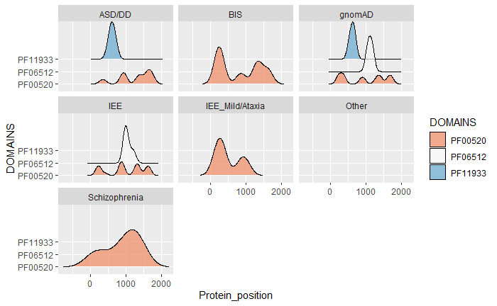

```r
ggplot(d_pf1, aes(x = Protein_position, y = DOMAINS)) +
  geom_density_ridges(scale = 3, alpha = 0.7, aes(fill = DOMAINS)) +
  scale_fill_brewer(palette = "RdBu") +
  facet_wrap(Group ~ .)
```

### Trial 2. density

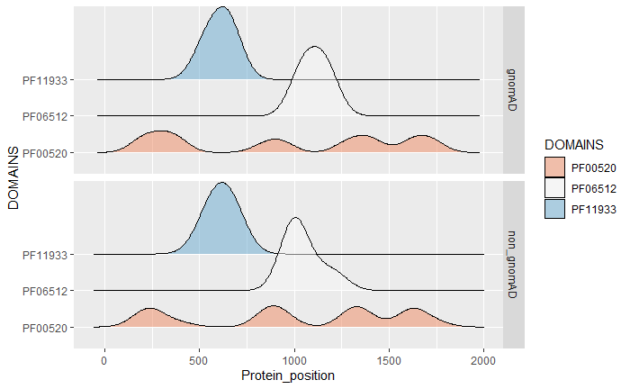

```r
ggplot(d_pf1, aes(x = Protein_position, y = DOMAINS)) +
  geom_density_ridges(scale = 2, alpha = 0.5, aes(fill = DOMAINS)) +
  scale_fill_brewer(palette = "RdBu") +
  facet_grid(Group2 ~ .)
```

### Trial 3. scatter

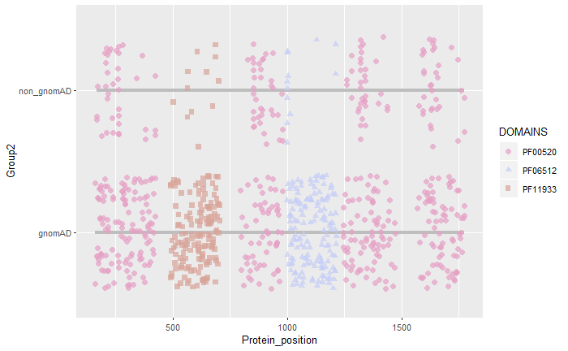

```r
d_pf1 %>% ggplot(aes(x = Protein_position, y = Group2)) +
  geom_line(color = "gray", size = 1.5 )+
  geom_jitter(position=position_jitter(0.2), alpha = 0.7, aes(color = DOMAINS, shape = DOMAINS), size = 2) +
  scale_color_manual(values=wes_palette(n=3, name="GrandBudapest2")) +
  theme_pubclean() +
  theme_gray(base_size = 10)
```

### Trial 4. lolliplot

```r
d_pf1 %>% ggplot(aes(x = Protein_position, y = Group2)) +
  geom_segment(aes(xend = Protein_position), yend = 0 )
  geom_point(size = 5, color = "red", fill = alpha("orange", 0.3), alpha = 0.7, shape = 21, stroke = 2)
```

[output not shown]